# Kaggle Seattle AirBNB

### CRISP-DM FRAMEWORK

1. Business Understanding
2. Data Understanding
3. Data Prepararation
4. Modeling
5. Evaluation

# BUSINESS UNDERSTANDING

Since 2008, guests and hosts have used Airbnb to travel in a more unique, personalized way. As part of the Airbnb Inside initiative, this dataset describes the listing activity of homestays in Seattle, WA. For this Udacity Data Scientist Nanodegree first project, we are using Seattle AirBNB data to analyze the following three business questions. We also provide the theses why we want to ask these questions.

1. Is there any relationship between number of reviews and monthly prices?  
   **Thesis**: the higher the price is the more number of reviews the listing will get. We assume people will expect since they pay so much money to rent a place. To analyze this question, we extract the monthly_price and reviews_per_month for each listing.
2. What is the impact of neighborhood on monthly prices?  
   **Thesis**: The monthly price will depend on the neighborhood. Since the housing prices in some neighborhood areas are more expensive, we can expect the AirBNB price will also tend to be higher in some areas.
3. Can We predict the monthly prices based on certain parameters?  
   **Thesis**. Other than the neighborhood, we believe there are certain characteristics in the listings that can help to predict the monthly price. Similar to the housing price, some characteristics (ie. independent variables), such as number of bedrooms, size, etc., have strong coefficient to the dependent variable (ie. monthly price).

For the first two questions above, we will use **data visualization and descriptive analytics** to answer the question. For the last question, we will use **sklearn linear regression model** to train and predict monthly prices based on *5 features selection* as described in details below.

# DATA UNDERSTANDING

**Methodology**

1. Download csv files from Kaggle Seattle AirBNB competition.
2. Upload the csv files into seattle folder.
3. Use `pd.read_csv()` function to import each csv file into dataframes.
4. To connect all the three dataframes, we set listing id as the primary key.
5. Combine all three dataframes into one dataframe using `df.join()` function with outer join since we find the union of the three dataframes. Since we are comparing the monthly_price against number of reviews in the first question and against neighborhood in the second question, we used regex to convert the dtype from string to float. Also, we have plenty of records in our dataframes. Therefore, we remove NaN data using `pd.dropna()` function.

**Data Exploration** The three csv files that we downloaded from Kaggle are:

1. `calendar.csv`: For each listing_id (ie. primary key), it contains date (datetime), available (boolean), and price (string). There are 1,393,570 records in this file.
2. `listings.csv`: This is the main file that has all information about a specific listing. This file has 91 columns, such as listing_url, scrape_id, name, summary, space, etc. There are 3,818 total listings in Seattle.
3. `reviews.csv`: This file includes the comments on specific listing. It includes information, such as review_id, name, comments, and date. There are 84849 comments in this file.

### Import libraries

```python
import pandas as pd
import numpy as np
import seaborn as sns
import matplotlib as mpl
import matplotlib.pyplot as plt
%matplotlib inline
mpl.rcParams['agg.path.chunksize'] = 10000

from sklearn import datasets, linear_model
from sklearn.metrics import mean_squared_error, r2_score
from sklearn.model_selection import train_test_split
```

### Import csv files

```python
calendar = pd.read_csv('./seattle/calendar.csv', index_col='listing_id')
calendar.head()
```

| listing_id | date | available | price |
| --- | --- | --- | --- |
| 241032 | 2016-01-04 | t | $85.00 |
| 241032 | 2016-01-05 | t | $85.00 |
| 241032 | 2016-01-06 | f | NaN |
| 241032 | 2016-01-07 | f | NaN |
| 241032 | 2016-01-08 | f | NaN |

```python
listings = pd.read_csv('./seattle/listings.csv', index_col='id')
listings.head()
```

| id | listing_url | scrape_id | last_scraped | name | summary | space | description | experiences_offered | neighborhood_overview | notes | ... | review_scores_value | requires_license | license | jurisdiction_names | instant_bookable | cancellation_policy | require_guest_profile_picture | require_guest_phone_verification | calculated_host_listings_count | reviews_per_month |
| --- | --- | --- | --- | --- | --- | --- | --- | --- | --- | --- | --- | --- | --- | --- | --- | --- | --- | --- | --- | --- | --- |
| 241032 | https://www.airbnb.com/rooms/241032 | 20160104002432 | 2016-01-04 | Stylish Queen Anne Apartment | NaN | Make your self at home in this charming one-be... | Make your self at home in this charming one-be... | none | NaN | NaN | ... | 10.0 | f | NaN | WASHINGTON | f | moderate | f | f | 2 | 4.07 |
| 953595 | https://www.airbnb.com/rooms/953595 | 20160104002432 | 2016-01-04 | Bright & Airy Queen Anne Apartment | Chemically sensitive? We've removed the irrita... | Beautiful, hypoallergenic apartment in an extr... | Chemically sensitive? We've removed the irrita... | none | Queen Anne is a wonderful, truly functional vi... | What's up with the free pillows? Our home was... | ... | 10.0 | f | NaN | WASHINGTON | f | strict | t | t | 6 | 1.48 |
| 3308979 | https://www.airbnb.com/rooms/3308979 | 20160104002432 | 2016-01-04 | New Modern House-Amazing water view | New modern house built in 2013. Spectacular s... | Our house is modern, light and fresh with a wa... | New modern house built in 2013. Spectacular s... | none | Upper Queen Anne is a charming neighborhood fu... | Our house is located just 5 short blocks to To... | ... | 10.0 | f | NaN | WASHINGTON | f | strict | f | f | 2 | 1.15 |
| 7421966 | https://www.airbnb.com/rooms/7421966 | 20160104002432 | 2016-01-04 | Queen Anne Chateau | A charming apartment that sits atop Queen Anne... | NaN | A charming apartment that sits atop Queen Anne... | none | NaN | NaN | ... | NaN | f | NaN | WASHINGTON | f | flexible | f | f | 1 | NaN |
| 278830 | https://www.airbnb.com/rooms/278830 | 20160104002432 | 2016-01-04 | Charming craftsman 3 bdm house | Cozy family craftman house in beautiful neighb... | Cozy family craftman house in beautiful neighb... | Cozy family craftman house in beautiful neighb... | none | We are in the beautiful neighborhood of Queen ... | Belltown | ... | 9.0 | f | NaN | WASHINGTON | f | strict | f | f | 1 | 0.89 |

5 rows × 91 columns

```python
reviews = pd.read_csv('./seattle/reviews.csv', index_col='listing_id')
reviews.head()
```

| listing_id | id | date | reviewer_id | reviewer_name | comments |
| --- | --- | --- | --- | --- | --- |
| 7202016 | 38917982 | 2015-07-19 | 28943674 | Bianca | Cute and cozy place. Perfect location to every... |
| 7202016 | 39087409 | 2015-07-20 | 32440555 | Frank | Kelly has a great room in a very central locat... |
| 7202016 | 39820030 | 2015-07-26 | 37722850 | Ian | Very spacious apartment, and in a great neighb... |
| 7202016 | 40813543 | 2015-08-02 | 33671805 | George | Close to Seattle Center and all it has to offe... |
| 7202016 | 41986501 | 2015-08-10 | 34959538 | Ming | Kelly was a great host and very accommodating ... |

### Data exploration

```python
calendar.shape
```

```
(1393570, 3)
```

```python
listings.shape
```

```
(3818, 91)
```

```python
reviews.shape
```

```
(84849, 5)
```

```python
calendar.index.unique()
```

```
Int64Index([  241032,   953595,  3308979,  7421966,   278830,  5956968,
             1909058,   856550,  4948745,  2493658,
            ...
             1844791,  6120046,   262764,  8578490,  3383329,  8101950,
             8902327, 10267360,  9604740, 10208623],
           dtype='int64', name='listing_id', length=3818)
```

```python
listings.index.unique()
```

```
Int64Index([  241032,   953595,  3308979,  7421966,   278830,  5956968,
             1909058,   856550,  4948745,  2493658,
            ...
             1844791,  6120046,   262764,  8578490,  3383329,  8101950,
             8902327, 10267360,  9604740, 10208623],
           dtype='int64', name='id', length=3818)
```

```python
reviews.index.unique()
```

```
Int64Index([7202016, 3946674, 7833113, 8308353, 4277026, 7735100, 4701141,
            7934963, 2934389, 6888107,
            ...
            9137899, 6971260, 3258386, 9352778,  830948, 4555997, 3424991,
            1179538, 3624990, 9727246],
           dtype='int64', name='listing_id', length=3191)
```

# DATA PREPARATION

### Concat dataframe

```python
all_frames = listings.join([calendar, reviews], how='outer')
all_frames.head(100)
```

|  | listing_url | scrape_id | last_scraped | name | summary | space | description | experiences_offered | neighborhood_overview | notes | ... | calculated_host_listings_count | reviews_per_month | date_x | available | price_y | id | date_y | reviewer_id | reviewer_name | comments |
| --- | --- | --- | --- | --- | --- | --- | --- | --- | --- | --- | --- | --- | --- | --- | --- | --- | --- | --- | --- | --- | --- |
| 3335 | https://www.airbnb.com/rooms/3335 | 20160104002432 | 2016-01-04 | Sweet Seattle Urban Homestead 2 Bdr | Welcome! If you stay here you will be living i... | Welcome! Come enjoy your time in Seattle at a... | Welcome! If you stay here you will be living i... | none | This is a very diverse neighborhood with a var... | We are an urban farmy oasis and invite you to ... | ... | 4 | NaN | 2016-01-04 | f | NaN | NaN | NaN | NaN | NaN | NaN |
| 3335 | https://www.airbnb.com/rooms/3335 | 20160104002432 | 2016-01-04 | Sweet Seattle Urban Homestead 2 Bdr | Welcome! If you stay here you will be living i... | Welcome! Come enjoy your time in Seattle at a... | Welcome! If you stay here you will be living i... | none | This is a very diverse neighborhood with a var... | We are an urban farmy oasis and invite you to ... | ... | 4 | NaN | 2016-01-05 | f | NaN | NaN | NaN | NaN | NaN | NaN |
| 3335 | https://www.airbnb.com/rooms/3335 | 20160104002432 | 2016-01-04 | Sweet Seattle Urban Homestead 2 Bdr | Welcome! If you stay here you will be living i... | Welcome! Come enjoy your time in Seattle at a... | Welcome! If you stay here you will be living i... | none | This is a very diverse neighborhood with a var... | We are an urban farmy oasis and invite you to ... | ... | 4 | NaN | 2016-01-06 | f | NaN | NaN | NaN | NaN | NaN | NaN |
| 3335 | https://www.airbnb.com/rooms/3335 | 20160104002432 | 2016-01-04 | Sweet Seattle Urban Homestead 2 Bdr | Welcome! If you stay here you will be living i... | Welcome! Come enjoy your time in Seattle at a... | Welcome! If you stay here you will be living i... | none | This is a very diverse neighborhood with a var... | We are an urban farmy oasis and invite you to ... | ... | 4 | NaN | 2016-01-07 | f | NaN | NaN | NaN | NaN | NaN | NaN |
| 3335 | https://www.airbnb.com/rooms/3335 | 20160104002432 | 2016-01-04 | Sweet Seattle Urban Homestead 2 Bdr | Welcome! If you stay here you will be living i... | Welcome! Come enjoy your time in Seattle at a... | Welcome! If you stay here you will be living i... | none | This is a very diverse neighborhood with a var... | We are an urban farmy oasis and invite you to ... | ... | 4 | NaN | 2016-01-08 | f | NaN | NaN | NaN | NaN | NaN | NaN |
| ... | ... | ... | ... | ... | ... | ... | ... | ... | ... | ... | ... | ... | ... | ... | ... | ... | ... | ... | ... | ... | ... |
| 3335 | https://www.airbnb.com/rooms/3335 | 20160104002432 | 2016-01-04 | Sweet Seattle Urban Homestead 2 Bdr | Welcome! If you stay here you will be living i... | Welcome! Come enjoy your time in Seattle at a... | Welcome! If you stay here you will be living i... | none | This is a very diverse neighborhood with a var... | We are an urban farmy oasis and invite you to ... | ... | 4 | NaN | 2016-04-08 | t | $120.00 | NaN | NaN | NaN | NaN | NaN |
| 3335 | https://www.airbnb.com/rooms/3335 | 20160104002432 | 2016-01-04 | Sweet Seattle Urban Homestead 2 Bdr | Welcome! If you stay here you will be living i... | Welcome! Come enjoy your time in Seattle at a... | Welcome! If you stay here you will be living i... | none | This is a very diverse neighborhood with a var... | We are an urban farmy oasis and invite you to ... | ... | 4 | NaN | 2016-04-09 | t | $120.00 | NaN | NaN | NaN | NaN | NaN |
| 3335 | https://www.airbnb.com/rooms/3335 | 20160104002432 | 2016-01-04 | Sweet Seattle Urban Homestead 2 Bdr | Welcome! If you stay here you will be living i... | Welcome! Come enjoy your time in Seattle at a... | Welcome! If you stay here you will be living i... | none | This is a very diverse neighborhood with a var... | We are an urban farmy oasis and invite you to ... | ... | 4 | NaN | 2016-04-10 | t | $120.00 | NaN | NaN | NaN | NaN | NaN |
| 3335 | https://www.airbnb.com/rooms/3335 | 20160104002432 | 2016-01-04 | Sweet Seattle Urban Homestead 2 Bdr | Welcome! If you stay here you will be living i... | Welcome! Come enjoy your time in Seattle at a... | Welcome! If you stay here you will be living i... | none | This is a very diverse neighborhood with a var... | We are an urban farmy oasis and invite you to ... | ... | 4 | NaN | 2016-04-11 | t | $120.00 | NaN | NaN | NaN | NaN | NaN |
| 3335 | https://www.airbnb.com/rooms/3335 | 20160104002432 | 2016-01-04 | Sweet Seattle Urban Homestead 2 Bdr | Welcome! If you stay here you will be living i... | Welcome! Come enjoy your time in Seattle at a... | Welcome! If you stay here you will be living i... | none | This is a very diverse neighborhood with a var... | We are an urban farmy oasis and invite you to ... | ... | 4 | NaN | 2016-04-12 | t | $120.00 | NaN | NaN | NaN | NaN | NaN |

100 rows × 99 columns

```python
all_frames.shape
```

```
(31198740, 99)
```

```python
all_frames.columns
```

```
Index(['listing_url', 'scrape_id', 'last_scraped', 'name', 'summary', 'space',
       'description', 'experiences_offered', 'neighborhood_overview', 'notes',
       'transit', 'thumbnail_url', 'medium_url', 'picture_url',
       'xl_picture_url', 'host_id', 'host_url', 'host_name', 'host_since',
       'host_location', 'host_about', 'host_response_time',
       'host_response_rate', 'host_acceptance_rate', 'host_is_superhost',
       'host_thumbnail_url', 'host_picture_url', 'host_neighbourhood',
       'host_listings_count', 'host_total_listings_count',
       'host_verifications', 'host_has_profile_pic', 'host_identity_verified',
       'street', 'neighbourhood', 'neighbourhood_cleansed',
       'neighbourhood_group_cleansed', 'city', 'state', 'zipcode', 'market',
       'smart_location', 'country_code', 'country', 'latitude', 'longitude',
       'is_location_exact', 'property_type', 'room_type', 'accommodates',
       'bathrooms', 'bedrooms', 'beds', 'bed_type', 'amenities', 'square_feet',
       'price_x', 'weekly_price', 'monthly_price', 'security_deposit',
       'cleaning_fee', 'guests_included', 'extra_people', 'minimum_nights',
       'maximum_nights', 'calendar_updated', 'has_availability',
       'availability_30', 'availability_60', 'availability_90',
       'availability_365', 'calendar_last_scraped', 'number_of_reviews',
       'first_review', 'last_review', 'review_scores_rating',
       'review_scores_accuracy', 'review_scores_cleanliness',
       'review_scores_checkin', 'review_scores_communication',
       'review_scores_location', 'review_scores_value', 'requires_license',
       'license', 'jurisdiction_names', 'instant_bookable',
       'cancellation_policy', 'require_guest_profile_picture',
       'require_guest_phone_verification', 'calculated_host_listings_count',
       'reviews_per_month', 'date_x', 'available', 'price_y', 'id', 'date_y',
       'reviewer_id', 'reviewer_name', 'comments'],
      dtype='object')
```

```python
all_frames.dtypes
```

```
listing_url       object
scrape_id          int64
last_scraped      object
name              object
summary           object
                  ...
id               float64
date_y            object
reviewer_id      float64
reviewer_name     object
comments          object
Length: 99, dtype: object
```

# MODELING

## Question 1: Is there any relationship between number of reviews and monthly prices?

```python
listing_average_monthly_price = all_frames['monthly_price'].groupby(all_frames.index).max()
listing_average_monthly_price = listing_average_monthly_price.replace('[\$,)]','', regex=True).astype(float).dropna().sort_values(ascending=False)
listing_average_monthly_price
```

```
7733192    19500.0
2459519    19000.0
4464824    14900.0
7439802    14559.0
368403     13500.0
            ...
7074024      588.0
8566475      550.0
799882       520.0
6717555      500.0
921571       500.0
Name: monthly_price, Length: 1517, dtype: float64
```

```python
top_reviews_per_month = all_frames['reviews_per_month'].groupby(all_frames.index).count().sort_values(ascending=False)
top_reviews_per_month.head(10)
```

```
208356    173010
365550    170090
25002     147460
47196     128845
63308     116800
92835     116435
5682      108405
279063    107310
53867     104755
841049    101835
Name: reviews_per_month, dtype: int64
```

```python
review_and_price = listing_average_monthly_price.to_frame().join(top_reviews_per_month, how='left')
review_and_price
```

|  | monthly_price | reviews_per_month |
| --- | --- | --- |
| 7733192 | 19500.0 | 4380 |
| 2459519 | 19000.0 | 4745 |
| 4464824 | 14900.0 | 1825 |
| 7439802 | 14559.0 | 2555 |
| 368403 | 13500.0 | 1825 |
| ... | ... | ... |
| 7074024 | 588.0 | 1460 |
| 8566475 | 550.0 | 0 |
| 799882 | 520.0 | 11680 |
| 6717555 | 500.0 | 365 |
| 921571 | 500.0 | 2555 |

1517 rows × 2 columns

```
array([[<matplotlib.axes._subplots.AxesSubplot object at 0x1a3612198>]],
      dtype=object)
```

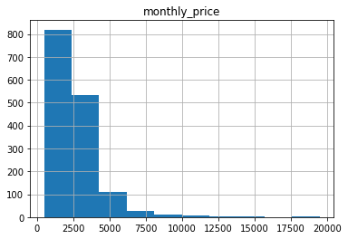

```python
review_and_price.hist('monthly_price', bins=10)
```

```
array([[<matplotlib.axes._subplots.AxesSubplot object at 0x170835b38>]],
      dtype=object)
```

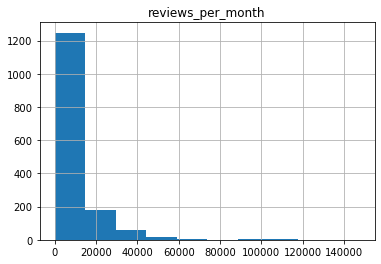

```python
review_and_price.hist('reviews_per_month', bins=10)
```

```python
review_and_price.corr()
```

|  | monthly_price | reviews_per_month |
| --- | --- | --- |
| monthly_price | 1.000000 | -0.027049 |
| reviews_per_month | -0.027049 | 1.000000 |

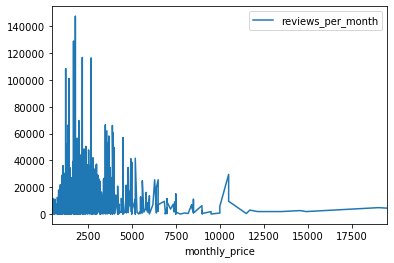

```python
review_and_price.plot(x='monthly_price', y='reviews_per_month')
```

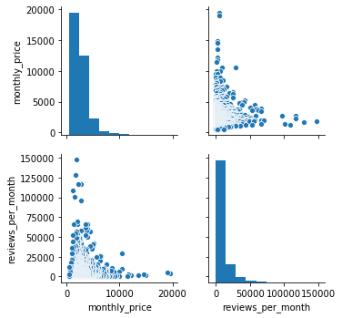

```python
sns.pairplot(review_and_price)
```

## Question 2: What is the impact of neighborhood on monthly prices?

```python
unique_neighborhood = all_frames['neighbourhood_cleansed'].unique()
unique_neighborhood
```

```
array(['Dunlap', 'Roosevelt', 'South Delridge', 'Wallingford', 'Broadway',
       'Georgetown', 'First Hill', 'Fairmount Park', 'Maple Leaf',
       'Green Lake', 'Belltown', 'Adams', 'Holly Park', 'Windermere',
       'Whittier Heights', 'Loyal Heights', 'Fremont', 'Mid-Beacon Hill',
       'Stevens', 'Wedgwood', 'South Lake Union', 'Genesee', 'Ravenna',
       'Greenwood', 'Montlake', 'West Woodland', 'Seward Park',
       'Eastlake', 'Highland Park', 'Leschi', 'Crown Hill',
       'North Admiral', 'Central Business District', 'Phinney Ridge',
       'Haller Lake', 'North Queen Anne', 'Atlantic', 'Alki',
       'Harrison/Denny-Blaine', 'North Beacon Hill', 'Mann', 'Seaview',
       'Matthews Beach', 'Sunset Hill', 'East Queen Anne',
       'Lower Queen Anne', 'Rainier Beach', 'West Queen Anne',
       'Lawton Park', 'Columbia City', 'Gatewood', 'Bryant',
       'International District', 'North Beach/Blue Ridge',
       'North Delridge', 'University District', 'Minor', 'Arbor Heights',
       'Madrona', 'Broadview', 'Cedar Park', 'Briarcliff', 'Riverview',
       'Fauntleroy', 'Olympic Hills', 'Mount Baker', 'North College Park',
       'Pioneer Square', 'Westlake', 'Victory Heights', 'Pike-Market',
       'Brighton', 'Madison Park', 'High Point', 'Meadowbrook',
       'Bitter Lake', 'Laurelhurst', 'Industrial District',
       'South Beacon Hill', 'Southeast Magnolia', 'Interbay',
       'Portage Bay', 'View Ridge', 'Yesler Terrace', 'Pinehurst',
       'South Park', 'Roxhill'], dtype=object)
```

```python
unique_neighborhood.size
```

```
87
```

```python
neigborhood_and_price = pd.DataFrame()
neigborhood_and_price['monthly_price'] = all_frames['monthly_price']
neigborhood_and_price['neighbourhood_cleansed'] = all_frames['neighbourhood_cleansed']
neigborhood_and_price['monthly_price'] = neigborhood_and_price['monthly_price'].replace('[\$,)]','', regex=True).astype(float)
neigborhood_and_price = neigborhood_and_price.dropna()
neigborhood_and_price
```

|  | monthly_price | neighbourhood_cleansed |
| --- | --- | --- |
| 3335 | 1600.0 | Dunlap |
| 3335 | 1600.0 | Dunlap |
| 3335 | 1600.0 | Dunlap |
| 3335 | 1600.0 | Dunlap |
| 3335 | 1600.0 | Dunlap |
| ... | ... | ... |
| 10331249 | 995.0 | North Admiral |
| 10331249 | 995.0 | North Admiral |
| 10331249 | 995.0 | North Admiral |
| 10331249 | 995.0 | North Admiral |
| 10331249 | 995.0 | North Admiral |

13229060 rows × 2 columns

```python
grouped_by_neighboorhood = neigborhood_and_price.groupby('neighbourhood_cleansed').mean().sort_values(ascending=False, by='monthly_price').dropna()
grouped_by_neighboorhood
```

| neighbourhood_cleansed | monthly_price |
| --- | --- |
| Portage Bay | 6302.597403 |
| Briarcliff | 4604.545455 |
| Pike-Market | 4348.207692 |
| South Lake Union | 3965.653595 |
| Central Business District | 3662.375459 |
| ... | ... |
| Georgetown | 1400.752137 |
| South Delridge | 1390.218659 |
| Wedgwood | 1331.795455 |
| Victory Heights | 1122.549550 |
| Arbor Heights | 950.000000 |

84 rows × 1 columns

```python
neigborhood_and_price['monthly_price'].describe()
```

[output not shown]

[figure not shown]

```python
sns.distplot(neigborhood_and_price['monthly_price'], hist=False, bins=20);
```

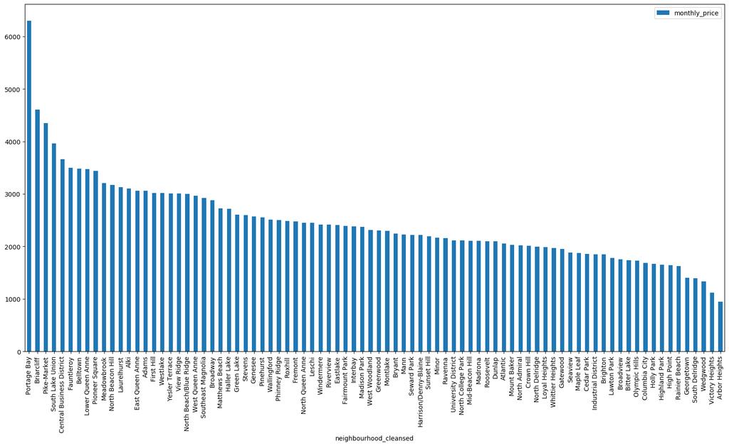

```python
grouped_by_neighboorhood.plot(figsize=(20, 10), kind='bar')
```

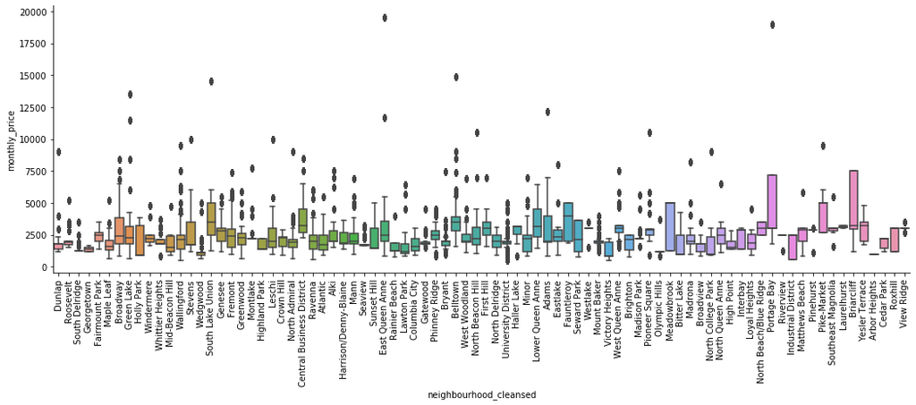

```python
g = sns.catplot(x="neighbourhood_cleansed", y="monthly_price", kind="box", data=neigborhood_and_price, aspect=3)
g.set_xticklabels(rotation=90)
```

### Question 3: Can we rredict the monthly prices?

```python
all_frames.columns
```

```
Index(['listing_url', 'scrape_id', 'last_scraped', 'name', 'summary', 'space',
       'description', 'experiences_offered', 'neighborhood_overview', 'notes',
       'transit', 'thumbnail_url', 'medium_url', 'picture_url',
       'xl_picture_url', 'host_id', 'host_url', 'host_name', 'host_since',
       'host_location', 'host_about', 'host_response_time',
       'host_response_rate', 'host_acceptance_rate', 'host_is_superhost',
       'host_thumbnail_url', 'host_picture_url', 'host_neighbourhood',
       'host_listings_count', 'host_total_listings_count',
       'host_verifications', 'host_has_profile_pic', 'host_identity_verified',
       'street', 'neighbourhood', 'neighbourhood_cleansed',
       'neighbourhood_group_cleansed', 'city', 'state', 'zipcode', 'market',
       'smart_location', 'country_code', 'country', 'latitude', 'longitude',
       'is_location_exact', 'property_type', 'room_type', 'accommodates',
       'bathrooms', 'bedrooms', 'beds', 'bed_type', 'amenities', 'square_feet',
       'price_x', 'weekly_price', 'monthly_price', 'security_deposit',
       'cleaning_fee', 'guests_included', 'extra_people', 'minimum_nights',
       'maximum_nights', 'calendar_updated', 'has_availability',
       'availability_30', 'availability_60', 'availability_90',
       'availability_365', 'calendar_last_scraped', 'number_of_reviews',
       'first_review', 'last_review', 'review_scores_rating',
       'review_scores_accuracy', 'review_scores_cleanliness',
       'review_scores_checkin', 'review_scores_communication',
       'review_scores_location', 'review_scores_value', 'requires_license',
       'license', 'jurisdiction_names', 'instant_bookable',
       'cancellation_policy', 'require_guest_profile_picture',
       'require_guest_phone_verification', 'calculated_host_listings_count',
       'reviews_per_month', 'date_x', 'available', 'price_y', 'id', 'date_y',
       'reviewer_id', 'reviewer_name', 'comments'],
      dtype='object')
```

```python
train_data = all_frames[['monthly_price', 'bathrooms', 'bedrooms', 'beds','review_scores_rating', 'number_of_reviews']]
train_data['monthly_price'] = train_data['monthly_price'].replace('[\$,)]','', regex=True).astype(float)
train_data = train_data.dropna()
train_data
```

|  | monthly_price | bathrooms | bedrooms | beds | review_scores_rating | number_of_reviews |
| --- | --- | --- | --- | --- | --- | --- |
| 4291 | 1925.0 | 1.0 | 1.0 | 1.0 | 92.0 | 35 |
| 4291 | 1925.0 | 1.0 | 1.0 | 1.0 | 92.0 | 35 |
| 4291 | 1925.0 | 1.0 | 1.0 | 1.0 | 92.0 | 35 |
| 4291 | 1925.0 | 1.0 | 1.0 | 1.0 | 92.0 | 35 |
| 4291 | 1925.0 | 1.0 | 1.0 | 1.0 | 92.0 | 35 |
| ... | ... | ... | ... | ... | ... | ... |
| 9863484 | 1600.0 | 1.0 | 0.0 | 1.0 | 100.0 | 2 |
| 9863484 | 1600.0 | 1.0 | 0.0 | 1.0 | 100.0 | 2 |
| 9863484 | 1600.0 | 1.0 | 0.0 | 1.0 | 100.0 | 2 |
| 9863484 | 1600.0 | 1.0 | 0.0 | 1.0 | 100.0 | 2 |
| 9863484 | 1600.0 | 1.0 | 0.0 | 1.0 | 100.0 | 2 |

13041815 rows × 6 columns

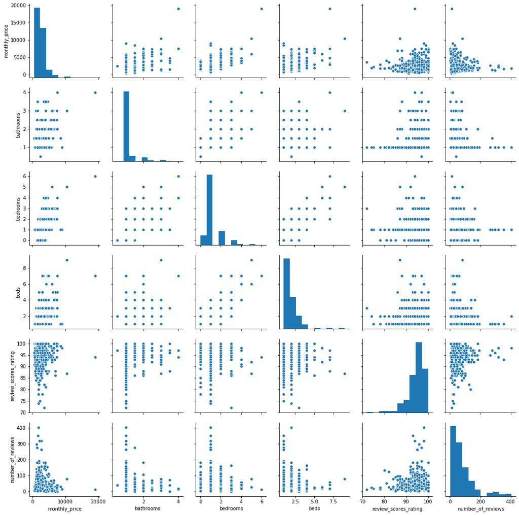

```python
sns.pairplot(train_data.sample(1000))
```

```python
y = train_data['monthly_price']
X = train_data[['bathrooms', 'bedrooms', 'beds','review_scores_rating', 'number_of_reviews']]
```

```python
X_train, X_test, y_train, y_test = train_test_split(X, y, test_size=0.33, random_state=42)
```

```python
X_test.shape
```

```
(4303799, 5)
```

```python
y_test.shape
```

```
(4303799,)
```

```python
regr = linear_model.LinearRegression()
regr.fit(X_train, y_train)
```

```
LinearRegression(copy_X=True, fit_intercept=True, n_jobs=None, normalize=False)
```

```python
y_pred = regr.predict(X_test)
y_pred
```

```
array([2201.1941276 , 1368.69285635, 5106.4573218 , ..., 2081.05102837,
       2271.63960352, 5490.26999533])
```

```python
print('Coefficients: \n', regr.coef_)
print("Mean squared error: %.2f" % mean_squared_error(y_test, y_pred))
print('Variance score: %.2f' % r2_score(y_test, y_pred))
```

```
Coefficients:
 [557.85128584 436.79682235 391.29903254  30.64544669  -0.6715895 ]
Mean squared error: 1308632.06
Variance score: 0.34
```

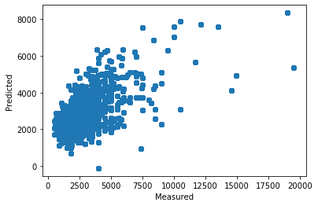

```python
fig, ax = plt.subplots()
ax.scatter(y_test, y_pred)
ax.set_xlabel('Measured')
ax.set_ylabel('Predicted')
plt.show()
```

# EVALUATION

### Question 1: Is there any relationship between number of reviews and monthly prices?

As shown in the correlation table and data visualization, we can conclude there is no relationship between monthly price and number of reviews per month. The correlation is close to 0 which means both variables don’t correlate with each other.

### Question 2: What is the impact of neighborhood on monthly prices?

Since we are comparing the price (dtype: float) versus neighborhoods (dtype: categorical data), we can’t compute the correlation between the two variables. However, as we can see from the data visualization, we can infer the relationship between monthly price and neighborhood areas. We also omit three neighborhood areas that don't show monthly prices. We believe removing these neighborhood not only won't impact the conclusion for this question, but also help keep the data clean from any `NaN` values.

### Question 3: Can we predict the monthly prices?

The linear regression performs much better than the first analysis. With 5 features selection, the model can predict much better than the random variable that we selected to analyze the first question. When we have much bigger computing power, we can try to use more features and try to improve the prediction better.